# Chapter 15. Autoencoders

autoencoder는 coding이라고 불리는 input data의 효율적인 표현을 학습하는데 유용한 인공신경망이다. 이런 coding들은 전형적으로 input data보다 훨씬 더 적은 차원을 가진다. 그리고 이것은 autoencoder를 차원축소에 있어서 유용하게 만들어준다. 더 중요한것은, autoencoder는 강력한 feature detector로 동작하고 그들은 deep neural networks의 비지도 pretraining에 사용될 수 있다. 그들은 랜덤하게 training data와 비슷한 새로운 data를 생성할 수 있고 이것을 generative model이라고 부른다. autoencoder는 input을 output에 복사하는 법을 배움으로써 동작한다. coding은 몇몇 제약조건아래에 identity function을 학습하기 위한 autoencoder의 시도의 부산물이다.

이번 장에서 우리는 어떻게 autoencoder가 동작하고, 어떤 유형의 제약조건이 부과되고, 그들을 Tensorflow상에서 어떻게 구현하는지 알아볼 것이다.(차원축소,feature extraction, unsupervised-pretraining,generative models)

# Setup

First, let's make sure this notebook works well in both python 2 and 3, import a few common modules, ensure MatplotLib plots figures inline and prepare a function to save the figures:

```python
# To support both python 2 and python 3
from __future__ import division, print_function, unicode_literals

# Common imports
import numpy as np
import os
import sys

# to make this notebook's output stable across runs
def reset_graph(seed=42):
    tf.reset_default_graph()
    tf.set_random_seed(seed)
    np.random.seed(seed)

# To plot pretty figures
%matplotlib inline
import matplotlib
import matplotlib.pyplot as plt
plt.rcParams['axes.labelsize'] = 14
plt.rcParams['xtick.labelsize'] = 12
plt.rcParams['ytick.labelsize'] = 12

# Where to save the figures
PROJECT_ROOT_DIR = "."
CHAPTER_ID = "autoencoders"

def save_fig(fig_id, tight_layout=True):
    path = os.path.join(PROJECT_ROOT_DIR, "images", CHAPTER_ID, fig_id + ".png")
    print("Saving figure", fig_id)
    if tight_layout:
        plt.tight_layout()
    plt.savefig(path, format='png', dpi=300)
```

A couple utility functions to plot grayscale 28x28 image:

```python
def plot_image(image, shape=[28, 28]):
    plt.imshow(image.reshape(shape), cmap="Greys", interpolation="nearest")
    plt.axis("off")
```

```python
def plot_multiple_images(images, n_rows, n_cols, pad=2):
    images = images - images.min()  # make the minimum == 0, so the padding looks white
    w,h = images.shape[1:]
    image = np.zeros(((w+pad)*n_rows+pad, (h+pad)*n_cols+pad))
    for y in range(n_rows):
        for x in range(n_cols):
            image[(y*(h+pad)+pad):(y*(h+pad)+pad+h),(x*(w+pad)+pad):(x*(w+pad)+pad+w)] = images[y*n_cols+x]
    plt.imshow(image, cmap="Greys", interpolation="nearest")
    plt.axis("off")
```

## 1. Efficient Data Representations

- 40,27,25,36,81,57,10,73,19,68
- 50,25,76,38,19,58,29,88,44,22,11,34,17,52,26,13,40,20

처음 위의 시퀀스들을 봤을 때 첫번째 시퀀스가 짧아서 더 외우기 쉬워보인다. 하지만, 두번째 시퀀스를 자세히 들여다보면 우리는 두가지 규칙을 발견할수 있다. 첫번째는 짝수의 경우 절반의 값이 바로 뒤에 나온다는 점, 두번째는 홀수의 경우 그 수의 3배에 1을 더한 수가 다음에 나온다는 점이다. 우리가 이러한 패턴을 발견하면 첫번째 시퀀스보다 두번째 시퀀스가 훨씬 더 외우기 쉬울것이다. 패턴을 인식하는데 도움이 되는 긴 시퀀스를 외우는 것이 어렵다라는 사실은 학습도중 autoencoder를 제한하는 것이 데이터의 패턴을 발견하고 악용하도록 하는 이유가 무엇인지 분명히 설명해준다.

기억,인지,그리고 패턴 matching사이의 관계는 Willam과 Herbert가 1970년대 초기에 연구했다. 그들은 전문 체스 선수들이 5초동안 보드를 바라봄으로써 게임에서의 모든 말의 위치를 기억할 수 있다는것을 발견했다. 그러나, 이것은 오직 말들이 현실적인 위치에 놓였을때만 가능하다. 체스 전문가들은 우리보다 더 나는 기억력을 가진것이 아니다. 그들은 단지 게임에서의 그들의 경험 덕분에 더 쉽게 체스 패턴을 보는것이다. 패턴을 알아내는것은 그들이 정보를 더 효율적으로 저장하게 한다.

기억실험에서 체스 선수들처럼, autoencoder는 input들을 바라보고, 그것들을 효율적인 내부의 표현으로 바꾸고, input과 가장 유사한 어떤 것을 내보낸다. autoencoder는 encoder와 decoder 두 부분으로 나눠져있다.

내부 표현은 input data보다 더 적은 차원을 가지기때문에 autoencoder는 undercomplete라고 말하기도한다.

## 2. Perfoming PCA with an Undercomplete Linear Autoencoder

만약 autoencoder가 오직 linear activation만을 사용하고 비용함수가 Mean Squared Error라면, 결국 이것은 PCA를 수행하게된다.

다음 코드는 PCA를 수행하기 위해 선형의 autoencoder를 만든다.

```python
import tensorflow as tf

reset_graph()

n_inputs = 3
n_hidden = 2  # codings
n_outputs = n_inputs

learning_rate = 0.01

X = tf.placeholder(tf.float32, shape=[None, n_inputs])
hidden = tf.layers.dense(X, n_hidden)
outputs = tf.layers.dense(hidden, n_outputs)

reconstruction_loss = tf.reduce_mean(tf.square(outputs - X))

optimizer = tf.train.AdamOptimizer(learning_rate)
training_op = optimizer.minimize(reconstruction_loss)

init = tf.global_variables_initializer()
```

-주목할 점-

1. output의 수는 input의 수와 같다.
2. 단순한 PCA를 수행하기 위해, 우리는 어떠한 activation function도 사용하지않고 비용함수는 MSE이다.

```python
#3D를 2D에 projection
n_iterations = 1000
codings = hidden

with tf.Session() as sess:
    init.run()
    for iteration in range(n_iterations):
        training_op.run(feed_dict={X: X_train})
    codings_val = codings.eval(feed_dict={X: X_test})
```

```
Saving figure linear_autoencoder_pca_plot
```

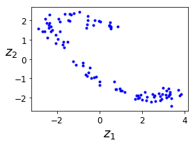

```python
fig = plt.figure(figsize=(4,3))
plt.plot(codings_val[:,0], codings_val[:, 1], "b.")
plt.xlabel("$z_1$", fontsize=18)
plt.ylabel("$z_2$", fontsize=18, rotation=0)
save_fig("linear_autoencoder_pca_plot")
plt.show()
```

## 3. Stacked Autoencoders

다른 neural network들처럼 autoencoder는 다양한 hidden layer들을 가지고 있다. 이 경우에 그들은 stacked autoencoders라고 불린다. 더 많은 layer들을 추가하는 것은 autoencoder가 더 복잡한 coding을 학습할 수있도록 한다. 그러나 autoencoder가 너무 강력해지지 않도록 해야한다.

stacked autoencoder의 아키텍쳐는 중앙의 hidden layer에 대해 대칭적이다. 이것은 샌드위치와 비슷한 형태이다.

Let's use MNIST:

```python
from tensorflow.examples.tutorials.mnist import input_data
mnist = input_data.read_data_sets("/tmp/data/")
```

### 3.1 Tensorflow Implementation

우리는 stacked autoencoder를 regular deep MLP처럼 실행할 수 있다.

아래의 코드는 MNIST에 대해 stacked autoencoder를 만든다.

```python
reset_graph()

from functools import partial

n_inputs = 28 * 28
n_hidden1 = 300
n_hidden2 = 150  # codings
n_hidden3 = n_hidden1
n_outputs = n_inputs

learning_rate = 0.01
l2_reg = 0.0001

X = tf.placeholder(tf.float32, shape=[None, n_inputs])

he_init = tf.contrib.layers.variance_scaling_initializer() # He initialization
#Equivalent to:
#he_init = lambda shape, dtype=tf.float32: tf.truncated_normal(shape, 0., stddev=np.sqrt(2/shape[0]))
l2_regularizer = tf.contrib.layers.l2_regularizer(l2_reg)
my_dense_layer = partial(tf.layers.dense,
                         activation=tf.nn.elu,
                         kernel_initializer=he_init,
                         kernel_regularizer=l2_regularizer)

hidden1 = my_dense_layer(X, n_hidden1)
hidden2 = my_dense_layer(hidden1, n_hidden2)
hidden3 = my_dense_layer(hidden2, n_hidden3)
outputs = my_dense_layer(hidden3, n_outputs, activation=None)

reconstruction_loss = tf.reduce_mean(tf.square(outputs - X))

reg_losses = tf.get_collection(tf.GraphKeys.REGULARIZATION_LOSSES)
loss = tf.add_n([reconstruction_loss] + reg_losses)

optimizer = tf.train.AdamOptimizer(learning_rate)
training_op = optimizer.minimize(loss)

init = tf.global_variables_initializer()
saver = tf.train.Saver() # not shown in the book
```

Now let's train it! Note that we don't feed target values (`y_batch` is not used). This is unsupervised training.

```python
n_epochs = 5
batch_size = 150

with tf.Session() as sess:
    init.run()
    for epoch in range(n_epochs):
        n_batches = mnist.train.num_examples // batch_size
        for iteration in range(n_batches):
            print("\r{}%".format(100 * iteration // n_batches), end="") # not shown in the book
            sys.stdout.flush()                                          # not shown
            X_batch, y_batch = mnist.train.next_batch(batch_size)
            sess.run(training_op, feed_dict={X: X_batch})
        loss_train = reconstruction_loss.eval(feed_dict={X: X_batch})   # not shown
        print("\r{}".format(epoch), "Train MSE:", loss_train)           # not shown
        saver.save(sess, "./my_model_all_layers.ckpt")                  # not shown
```

```
0 Train MSE: 0.0205375
1 Train MSE: 0.0114228
2 Train MSE: 0.0102233
3 Train MSE: 0.00990161
4 Train MSE: 0.0103758
```

This function loads the model, evaluates it on the test set (it measures the reconstruction error), then it displays the original image and its reconstruction:

```python
def show_reconstructed_digits(X, outputs, model_path = None, n_test_digits = 2):
    with tf.Session() as sess:
        if model_path:
            saver.restore(sess, model_path)
        X_test = mnist.test.images[:n_test_digits]
        outputs_val = outputs.eval(feed_dict={X: X_test})

    fig = plt.figure(figsize=(8, 3 * n_test_digits))
    for digit_index in range(n_test_digits):
        plt.subplot(n_test_digits, 2, digit_index * 2 + 1)
        plot_image(X_test[digit_index])
        plt.subplot(n_test_digits, 2, digit_index * 2 + 2)
        plot_image(outputs_val[digit_index])
```

```
INFO:tensorflow:Restoring parameters from ./my_model_all_layers.ckpt
Saving figure reconstruction_plot
```

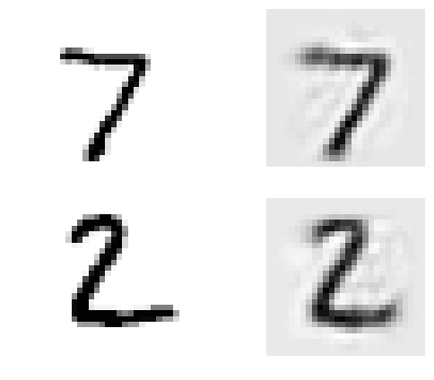

```python
show_reconstructed_digits(X, outputs, "./my_model_all_layers.ckpt")
save_fig("reconstruction_plot")
```

### 3.2 Tying weights

autoencoder가 대칭적일 때, 공통 기술은 decoder layer의 가중치를 encoder layer의 가중치에 엮는것이다. 이것은 모델의 가중치의 수를 반으로 줄여주고 학습의 속도를 높이고 overfitting의 위험을 줄여준다. TensorFlow에서 dense()함수를 사용하여 연결된 가중치를 실행하는 것은 조금 다루기힘들다. layer들을 직접 정의하는 것이 더 쉽다.

```python
reset_graph()

n_inputs = 28 * 28
n_hidden1 = 300
n_hidden2 = 150  # codings
n_hidden3 = n_hidden1
n_outputs = n_inputs

learning_rate = 0.01
l2_reg = 0.0005
```

```python
activation = tf.nn.elu
regularizer = tf.contrib.layers.l2_regularizer(l2_reg)
initializer = tf.contrib.layers.variance_scaling_initializer()

X = tf.placeholder(tf.float32, shape=[None, n_inputs])

weights1_init = initializer([n_inputs, n_hidden1])
weights2_init = initializer([n_hidden1, n_hidden2])

weights1 = tf.Variable(weights1_init, dtype=tf.float32, name="weights1")
weights2 = tf.Variable(weights2_init, dtype=tf.float32, name="weights2")
weights3 = tf.transpose(weights2, name="weights3")  # tied weights
weights4 = tf.transpose(weights1, name="weights4")  # tied weights

biases1 = tf.Variable(tf.zeros(n_hidden1), name="biases1")
biases2 = tf.Variable(tf.zeros(n_hidden2), name="biases2")
biases3 = tf.Variable(tf.zeros(n_hidden3), name="biases3")
biases4 = tf.Variable(tf.zeros(n_outputs), name="biases4")

hidden1 = activation(tf.matmul(X, weights1) + biases1)
hidden2 = activation(tf.matmul(hidden1, weights2) + biases2)
hidden3 = activation(tf.matmul(hidden2, weights3) + biases3)
outputs = tf.matmul(hidden3, weights4) + biases4

reconstruction_loss = tf.reduce_mean(tf.square(outputs - X))
reg_loss = regularizer(weights1) + regularizer(weights2)
loss = reconstruction_loss + reg_loss

optimizer = tf.train.AdamOptimizer(learning_rate)
training_op = optimizer.minimize(loss)

init = tf.global_variables_initializer()
```

```python
saver = tf.train.Saver()
```

```python
n_epochs = 5
batch_size = 150

with tf.Session() as sess:
    init.run()
    for epoch in range(n_epochs):
        n_batches = mnist.train.num_examples // batch_size
        for iteration in range(n_batches):
            print("\r{}%".format(100 * iteration // n_batches), end="")
            sys.stdout.flush()
            X_batch, y_batch = mnist.train.next_batch(batch_size)
            sess.run(training_op, feed_dict={X: X_batch})
        loss_train = reconstruction_loss.eval(feed_dict={X: X_batch})
        print("\r{}".format(epoch), "Train MSE:", loss_train)
        saver.save(sess, "./my_model_tying_weights.ckpt")
```

```
0 Train MSE: 0.0150667
1 Train MSE: 0.0164884
2 Train MSE: 0.0173757
3 Train MSE: 0.0168782
4 Train MSE: 0.0155875
```

```
INFO:tensorflow:Restoring parameters from ./my_model_tying_weights.ckpt
```

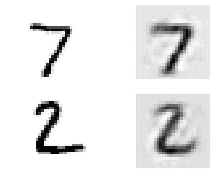

```python
show_reconstructed_digits(X, outputs, "./my_model_tying_weights.ckpt")
```

### 3.3 Training one Autoencoder at a time

전체 stacked autoencoder를 한번에 학습하는 것 대신에 한번에 하나의 얕은 autoencoder만 학습시키는 것이 더 빠르다. 이것은 종종 매우 깊은 autoencoder들에 사용된다.

이런 다 단계의 학습 알고리즘을 실행하기위한 가장 단순한 접근법은 각 단계마다 다른 TensorFlow 그래프를 사용하는 것이다. autoencoder를 학습한 후에, 우리는 이것을 통해 training set을 동작시키고 hidden layer의 출력을 확인할 수 있다. 이 출력은 다음 autoencoder를 위한 training set으로 활용된다. 모든 autoencoder들이 이런 방식으로 학습되면, 우리는 가중치와 bias들을 각각의 autoencoder로부터 복사해올수 있고 그것들을 stacked autoencoder를 만드는데에 사용할 수 있다.

```python
reset_graph()

n_inputs = 28 * 28
n_hidden1 = 300
n_hidden2 = 150  # codings
n_hidden3 = n_hidden1
n_outputs = n_inputs

learning_rate = 0.01
l2_reg = 0.0001

activation = tf.nn.elu
regularizer = tf.contrib.layers.l2_regularizer(l2_reg)
initializer = tf.contrib.layers.variance_scaling_initializer()

X = tf.placeholder(tf.float32, shape=[None, n_inputs])

weights1_init = initializer([n_inputs, n_hidden1])
weights2_init = initializer([n_hidden1, n_hidden2])
weights3_init = initializer([n_hidden2, n_hidden3])
weights4_init = initializer([n_hidden3, n_outputs])

weights1 = tf.Variable(weights1_init, dtype=tf.float32, name="weights1")
weights2 = tf.Variable(weights2_init, dtype=tf.float32, name="weights2")
weights3 = tf.Variable(weights3_init, dtype=tf.float32, name="weights3")
weights4 = tf.Variable(weights4_init, dtype=tf.float32, name="weights4")

biases1 = tf.Variable(tf.zeros(n_hidden1), name="biases1")
biases2 = tf.Variable(tf.zeros(n_hidden2), name="biases2")
biases3 = tf.Variable(tf.zeros(n_hidden3), name="biases3")
biases4 = tf.Variable(tf.zeros(n_outputs), name="biases4")

hidden1 = activation(tf.matmul(X, weights1) + biases1)
hidden2 = activation(tf.matmul(hidden1, weights2) + biases2)
hidden3 = activation(tf.matmul(hidden2, weights3) + biases3)
outputs = tf.matmul(hidden3, weights4) + biases4

reconstruction_loss = tf.reduce_mean(tf.square(outputs - X))
```

```python
optimizer = tf.train.AdamOptimizer(learning_rate)

with tf.name_scope("phase1"):
    phase1_outputs = tf.matmul(hidden1, weights4) + biases4  # bypass hidden2 and hidden3
    phase1_reconstruction_loss = tf.reduce_mean(tf.square(phase1_outputs - X))
    phase1_reg_loss = regularizer(weights1) + regularizer(weights4)
    phase1_loss = phase1_reconstruction_loss + phase1_reg_loss
    phase1_training_op = optimizer.minimize(phase1_loss)

with tf.name_scope("phase2"):
    phase2_reconstruction_loss = tf.reduce_mean(tf.square(hidden3 - hidden1))
    phase2_reg_loss = regularizer(weights2) + regularizer(weights3)
    phase2_loss = phase2_reconstruction_loss + phase2_reg_loss
    train_vars = [weights2, biases2, weights3, biases3]
    phase2_training_op = optimizer.minimize(phase2_loss, var_list=train_vars) # freeze hidden1
```

"첫번째 단계" 우리는 hidden layer 2와 3을 거치지 않는 output layer를 만든다. 그리고 output과 input사이의 거리를 최소화하기위한 학습 작업을 만든다.

"두번째 단계" 두번째 단계는 hidden layer 3과 hidden layer 1사이의 거리를 최소화하는데 필요한 작업을 더한다.

우리는 학습할만한 변수들의 리스트를 minimize()메소드를 사용하여 제공한다.

```python
init = tf.global_variables_initializer()
saver = tf.train.Saver()
```

```python
training_ops = [phase1_training_op, phase2_training_op]
reconstruction_losses = [phase1_reconstruction_loss, phase2_reconstruction_loss]
n_epochs = [4, 4]
batch_sizes = [150, 150]

with tf.Session() as sess:
    init.run()
    for phase in range(2):
        print("Training phase #{}".format(phase + 1))
        for epoch in range(n_epochs[phase]):
            n_batches = mnist.train.num_examples // batch_sizes[phase]
            for iteration in range(n_batches):
                print("\r{}%".format(100 * iteration // n_batches), end="")
                sys.stdout.flush()
                X_batch, y_batch = mnist.train.next_batch(batch_sizes[phase])
                sess.run(training_ops[phase], feed_dict={X: X_batch})
            loss_train = reconstruction_losses[phase].eval(feed_dict={X: X_batch})
            print("\r{}".format(epoch), "Train MSE:", loss_train)
            saver.save(sess, "./my_model_one_at_a_time.ckpt")
    loss_test = reconstruction_loss.eval(feed_dict={X: mnist.test.images})
    print("Test MSE:", loss_test)
```

```
Training phase #1
0 Train MSE: 0.00740679
1 Train MSE: 0.00782866
2 Train MSE: 0.00772802
3 Train MSE: 0.00740893
Training phase #2
0 Train MSE: 0.295499
1 Train MSE: 0.00594454
2 Train MSE: 0.00310264
3 Train MSE: 0.00249803
Test MSE: 0.00979144
```

### 3.4 Visualizing the Reconstructions

autoencoder가 제대로 학습되었다고 증명할 한가지 방법은 input과 output을 비교하는 것이다.

```
INFO:tensorflow:Restoring parameters from ./my_model_one_at_a_time.ckpt
```

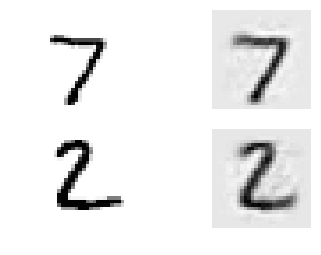

```python
n_test_digits = 2
X_test = mnist.test.images[:n_test_digits]

with tf.Session() as sess:
    saver.restore(sess, "./my_model_one_at_a_time.ckpt") # not shown in the book
    outputs_val = outputs.eval(feed_dict={X: X_test})

def plot_image(image, shape=[28, 28]):
    plt.imshow(image.reshape(shape), cmap="Greys", interpolation="nearest")
    plt.axis("off")

for digit_index in range(n_test_digits):
    plt.subplot(n_test_digits, 2, digit_index * 2 + 1)
    plot_image(X_test[digit_index])
    plt.subplot(n_test_digits, 2, digit_index * 2 + 2)
    plot_image(outputs_val[digit_index])
```

왼쪽: original digits / 오른쪽: their reconstructions

### 3.5 Visualizing the extracted features

몇가지 feature들을 확인할 수 있는 다양한 기술들이 있다. 가장 단순한 기술은 모든 hidden layer안에 있는 각 뉴런을 고려하여 이것을 가장 활성화시키는 training instance들을 찾아내는 것이다. 이것은 최상위 hidden layer에 가장 유용하다. 그러나 더 낮은 layer들에 있어서 이 기술은 잘 작동하지 않는다. 이는 feature들이 더 작고 더 추상적이기 때문이다. 그래서 어떤 뉴런이 더 활성화되는지 발견하는것이 어렵다. 또 다른 기술은 첫번째 hidden layer에서 각 뉴런에 대해, 픽셀의 강도가 주어진 뉴런에 대한 연결의 가중치에 해당하는 이미지를 만드는 것이다.

```
INFO:tensorflow:Restoring parameters from ./my_model_one_at_a_time.ckpt
Saving figure extracted_features_plot
```

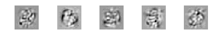

```python
with tf.Session() as sess:
    saver.restore(sess, "./my_model_one_at_a_time.ckpt") # not shown in the book
    weights1_val = weights1.eval()

for i in range(5):
    plt.subplot(1, 5, i + 1)
    plot_image(weights1_val.T[i])

save_fig("extracted_features_plot") # not shown
plt.show()                          # not shown
```

또다른 기술은 autoencoder에 random image를 주고 우리가 관심있는 부분의 뉴런 활성화를 측정하고 이미지를 수정하기 위한 역전파를 수행하는 것이다. 만약 몇번 반복하면, 이미지는 점차 가장 흥미있는 이미지로 바뀔 것이다. 이것은 뉴런이 찾는 input의 종류를 시각화하기에 가장 유용한 기술이다.

## 4. Unsupervised Pretraining Using Stacked Autoencoders

만약 우리가 복잡한 지도 학습을 다루지만 많은 라벨화된 training data가 없다면, 한가지 해결책은 비슷한 작업을 수행하는 neural network를 찾고 그것의 낮은 layer들을 재사용하는 것이다. 이것은 우리의 neural network가 저수준의 feature들을 모두 학습할 필요가 없기때문에 적은 training data를 사용하여 높은 수준의 모델을 학습시키는 것이 가능하다. 이것은 기존의 net에서 학습된 feature detector들을 재사용할 것이다. 유사하게, 만약 큰 dataset이지만 대부분이 라벨화되어있지않다면, 첫번재로 모든 데이터를 사용하여 stacked autoencoder를 학습하고 우리의 실제 작업을 위한 neural network를 만들기위해 가장 낮은 layer들을 재사용할 수 있다. 그리고 라벨화된 데이터를 사용하여 그것을 학습시킬 수 있다.

TensorFlow 실행에 있어 특별한 것은 없다. 단지 autoencoder를 모든 training data를 사용하여 학습시키고 새로운 neural network를 만들기 위해 이것의 encoder layer들을 재사용하는 것이다.

## 5. Denoising Autoencoders

autoencoder가 유용한 feature들을 학습하도록 하는 또다른 방법은 이것의 input에 노이즈를 추가하여 원래의 것을 회복하도록 학습시키는 것이다. 이것은 autoencoder가 이것의 input들을 output으로 쉽게 복사하는 것을 막고 이것은 결국 데이터에서 패턴을 찾게한다.

2010년 논문에서 Vincent는 stacked denoising autoencoders를 소개했다.

### 5.1 Tensorflow Implementation

input에 잡음을 더해준다는 것과 reconstruction loss가 원래의 input을 기반으로 계산된다는 것을 제외하고는 원래의 autoencoder를 학습하는 방법과 동일하다.

Gaussian noise 사용.

```python
reset_graph()

n_inputs = 28 * 28
n_hidden1 = 300
n_hidden2 = 150  # codings
n_hidden3 = n_hidden1
n_outputs = n_inputs

learning_rate = 0.01
```

```python
noise_level = 1.0

X = tf.placeholder(tf.float32, shape=[None, n_inputs])
X_noisy = X + noise_level * tf.random_normal(tf.shape(X))

hidden1 = tf.layers.dense(X_noisy, n_hidden1, activation=tf.nn.relu,
                          name="hidden1")
hidden2 = tf.layers.dense(hidden1, n_hidden2, activation=tf.nn.relu, # not shown in the book
                          name="hidden2")                            # not shown
hidden3 = tf.layers.dense(hidden2, n_hidden3, activation=tf.nn.relu, # not shown
                          name="hidden3")                            # not shown
outputs = tf.layers.dense(hidden3, n_outputs, name="outputs")        # not shown

reconstruction_loss = tf.reduce_mean(tf.square(outputs - X)) # MSE
```

```python
optimizer = tf.train.AdamOptimizer(learning_rate)
training_op = optimizer.minimize(reconstruction_loss)

init = tf.global_variables_initializer()
saver = tf.train.Saver()
```

```python
n_epochs = 10
batch_size = 150

with tf.Session() as sess:
    init.run()
    for epoch in range(n_epochs):
        n_batches = mnist.train.num_examples // batch_size
        for iteration in range(n_batches):
            print("\r{}%".format(100 * iteration // n_batches), end="")
            sys.stdout.flush()
            X_batch, y_batch = mnist.train.next_batch(batch_size)
            sess.run(training_op, feed_dict={X: X_batch})
        loss_train = reconstruction_loss.eval(feed_dict={X: X_batch})
        print("\r{}".format(epoch), "Train MSE:", loss_train)
        saver.save(sess, "./my_model_stacked_denoising_gaussian.ckpt")
```

```
0 Train MSE: 0.0440489
1 Train MSE: 0.0432517
2 Train MSE: 0.042057
3 Train MSE: 0.0409477
4 Train MSE: 0.0402107
5 Train MSE: 0.0388787
6 Train MSE: 0.0391096
7 Train MSE: 0.0421885
8 Train MSE: 0.0398648
9 Train MSE: 0.0408181
```

dropout 사용.

```python
reset_graph()

n_inputs = 28 * 28
n_hidden1 = 300
n_hidden2 = 150  # codings
n_hidden3 = n_hidden1
n_outputs = n_inputs

learning_rate = 0.01
```

```python
dropout_rate = 0.3

training = tf.placeholder_with_default(False, shape=(), name='training')

X = tf.placeholder(tf.float32, shape=[None, n_inputs])
X_drop = tf.layers.dropout(X, dropout_rate, training=training)

hidden1 = tf.layers.dense(X_drop, n_hidden1, activation=tf.nn.relu,
                          name="hidden1")
hidden2 = tf.layers.dense(hidden1, n_hidden2, activation=tf.nn.relu, # not shown in the book
                          name="hidden2")                            # not shown
hidden3 = tf.layers.dense(hidden2, n_hidden3, activation=tf.nn.relu, # not shown
                          name="hidden3")                            # not shown
outputs = tf.layers.dense(hidden3, n_outputs, name="outputs")        # not shown

reconstruction_loss = tf.reduce_mean(tf.square(outputs - X)) # MSE
```

```python
optimizer = tf.train.AdamOptimizer(learning_rate)
training_op = optimizer.minimize(reconstruction_loss)

init = tf.global_variables_initializer()
saver = tf.train.Saver()
```

```python
n_epochs = 10
batch_size = 150

with tf.Session() as sess:
    init.run()
    for epoch in range(n_epochs):
        n_batches = mnist.train.num_examples // batch_size
        for iteration in range(n_batches):
            print("\r{}%".format(100 * iteration // n_batches), end="")
            sys.stdout.flush()
            X_batch, y_batch = mnist.train.next_batch(batch_size)
            sess.run(training_op, feed_dict={X: X_batch, training: True})
        loss_train = reconstruction_loss.eval(feed_dict={X: X_batch})
        print("\r{}".format(epoch), "Train MSE:", loss_train)
        saver.save(sess, "./my_model_stacked_denoising_dropout.ckpt")
```

```
0 Train MSE: 0.0296476
1 Train MSE: 0.0275545
2 Train MSE: 0.0250731
3 Train MSE: 0.0254317
4 Train MSE: 0.0249076
5 Train MSE: 0.0250501
6 Train MSE: 0.024483
7 Train MSE: 0.0251505
8 Train MSE: 0.0243836
9 Train MSE: 0.0242349
```

```
INFO:tensorflow:Restoring parameters from ./my_model_stacked_denoising_dropout.ckpt
```

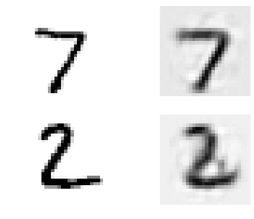

```python
show_reconstructed_digits(X, outputs, "./my_model_stacked_denoising_dropout.ckpt")
```

## 6. Sparse Autoencoders

좋은 feature 선택으로 이끄는 또다른 제약조건의 종류는 sparsity이다. 적절한 term을 비용함수에 추가함으로써, autoencoder는 coding layer의 활성화 뉴런의 수를 줄이기 위해 푸쉬된다. 이로 인해 autoencoder는 각 입력을 작은 수의 활성화 조합으로 나타내야한다. 그 결과, coding layer의 각 뉴런은 유용한 feature를 나타내게 된다.

분산 모델을 선택하기 위해, 우리는 처음으로 각 학습 단계에서 coding layer의 실제 희소성을 측정해야한다. 일단 우리가 뉴런당 mean activation을 가지면, 우리는 비용함수에 sparsity loss를 추가함으로써 너무 많이 활성화된 뉴런들을 사용하지 않는다. 한가지 방법은 단순히 제곱 오차를 비용함수에 더하는 것인데 실제로 더 나은 방법은 Kullback-Leibler divergence를 사용하는 것이다. 이것은 그림 15-10에서 보는 것처럼 Mean Squared Error보다 더 강한 gradient를 가진다.

```
Saving figure sparsity_loss_plot
```

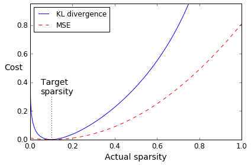

```python
p = 0.1
q = np.linspace(0.001, 0.999, 500)
kl_div = p * np.log(p / q) + (1 - p) * np.log((1 - p) / (1 - q))
mse = (p - q)**2
plt.plot([p, p], [0, 0.3], "k:")
plt.text(0.05, 0.32, "Target\nsparsity", fontsize=14)
plt.plot(q, kl_div, "b-", label="KL divergence")
plt.plot(q, mse, "r--", label="MSE")
plt.legend(loc="upper left")
plt.xlabel("Actual sparsity")
plt.ylabel("Cost", rotation=0)
plt.axis([0, 1, 0, 0.95])
save_fig("sparsity_loss_plot")
```

### 6.1 TensorFlow Implementation

```python
reset_graph()

n_inputs = 28 * 28
n_hidden1 = 1000  # sparse codings
n_outputs = n_inputs
```

```python
def kl_divergence(p, q):
    # Kullback Leibler divergence
    return p * tf.log(p / q) + (1 - p) * tf.log((1 - p) / (1 - q))

learning_rate = 0.01
sparsity_target = 0.1
sparsity_weight = 0.2

X = tf.placeholder(tf.float32, shape=[None, n_inputs])            # not shown in the book

hidden1 = tf.layers.dense(X, n_hidden1, activation=tf.nn.sigmoid) # not shown
outputs = tf.layers.dense(hidden1, n_outputs)                     # not shown

hidden1_mean = tf.reduce_mean(hidden1, axis=0) # batch mean
sparsity_loss = tf.reduce_sum(kl_divergence(sparsity_target, hidden1_mean))
reconstruction_loss = tf.reduce_mean(tf.square(outputs - X)) # MSE
loss = reconstruction_loss + sparsity_weight * sparsity_loss

optimizer = tf.train.AdamOptimizer(learning_rate)
training_op = optimizer.minimize(loss)
```

coding layer의 activation은 0과 1사이여야한다. 그렇지 않으면 KL divergence는 Not a Number(NaN)을 반환할 것이다.

```python
init = tf.global_variables_initializer()
saver = tf.train.Saver()
```

```python
n_epochs = 100
batch_size = 1000

with tf.Session() as sess:
    init.run()
    for epoch in range(n_epochs):
        n_batches = mnist.train.num_examples // batch_size
        for iteration in range(n_batches):
            print("\r{}%".format(100 * iteration // n_batches), end="")
            sys.stdout.flush()
            X_batch, y_batch = mnist.train.next_batch(batch_size)
            sess.run(training_op, feed_dict={X: X_batch})
        reconstruction_loss_val, sparsity_loss_val, loss_val = sess.run([reconstruction_loss, sparsity_loss, loss], feed_dict={X: X_batch})
        print("\r{}".format(epoch), "Train MSE:", reconstruction_loss_val, "\tSparsity loss:", sparsity_loss_val, "\tTotal loss:", loss_val)
        saver.save(sess, "./my_model_sparse.ckpt")
```

```
0 Train MSE: 0.134832 	Sparsity loss: 0.421739 	Total loss: 0.21918
1 Train MSE: 0.0587859 	Sparsity loss: 0.0108979 	Total loss: 0.0609655
2 Train MSE: 0.053738 	Sparsity loss: 0.0201038 	Total loss: 0.0577588
3 Train MSE: 0.0476169 	Sparsity loss: 0.0399679 	Total loss: 0.0556105
4 Train MSE: 0.0447499 	Sparsity loss: 0.0116199 	Total loss: 0.0470739
5 Train MSE: 0.0403685 	Sparsity loss: 0.0930409 	Total loss: 0.0589767
6 Train MSE: 0.0388338 	Sparsity loss: 0.0462908 	Total loss: 0.048092
7 Train MSE: 0.0378196 	Sparsity loss: 0.0758871 	Total loss: 0.052997
8 Train MSE: 0.0332092 	Sparsity loss: 0.0200693 	Total loss: 0.037223
9 Train MSE: 0.0314318 	Sparsity loss: 0.0965061 	Total loss: 0.050733
10 Train MSE: 0.0273777 	Sparsity loss: 0.0670885 	Total loss: 0.0407954
11 Train MSE: 0.0246779 	Sparsity loss: 0.0900828 	Total loss: 0.0426945
12 Train MSE: 0.0233311 	Sparsity loss: 0.0577432 	Total loss: 0.0348797
13 Train MSE: 0.0228954 	Sparsity loss: 0.0623308 	Total loss: 0.0353615
14 Train MSE: 0.0210913 	Sparsity loss: 0.0258186 	Total loss: 0.026255
```

[output cut: 85 more lines]

```
INFO:tensorflow:Restoring parameters from ./my_model_sparse.ckpt
```

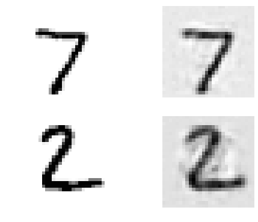

```python
show_reconstructed_digits(X, outputs, "./my_model_sparse.ckpt")
```

```python
hidden1 = tf.layers.dense(X, n_hidden1, activation=tf.nn.sigmoid)
```

MSE를 사용하는 것 대신에, 우리는 더 큰 gradient를 가지는 reconstruction loss를 선택할 수 있다. Cross entropy가 좋은 선택이다.

TensorFlow의 sigmoid_cross_entropy_with_logits()함수는 효율적으로 logistic activation 함수를 output에 적용하고 cross entropy를 계산한다.

```python
logits = tf.layers.dense(hidden1, n_outputs)
outputs = tf.nn.sigmoid(logits)

xentropy = tf.nn.sigmoid_cross_entropy_with_logits(labels=X, logits=logits)
reconstruction_loss = tf.reduce_mean(xentropy)
```

## 7. Variational Autoencoder

Variational Autoencoder는 우리가 다룬 모든 autoencoder와 조금 다르다.

- 그들은 probabilistic autoencdoers이다. 이것은 그들의 output이 부분적으로 우연히 결정되었다는 것을 의미한다.
- 그들은 generative autoencoders이다. 이것은 그들이 학습 셋으로부터 표본화 된 것처럼 보이는 새로은 인스턴스들을 만들수 있다는 것을 의미한다.

input이 나선형의 분포를 가지더라도, variational autoencoder는 그들이 단순 가우시안 분포로부터 표본화된것처럼 보이는 coding을 생성한다. 학습하는 동안,비용 함수는 coding을 서서히 이동시켜 가우시안 점의 구름처럼 보이는 구형의 영역을 차지하도록 coding 공간을 밀어 낸다.

한가지 엄청난 결과는 variational autoencoder를 학습시킨후에 우리는 쉽게 새로운 인스턴스를 생성할 수 있다는 것이다.

비용함수는 크게 두가지 부분으로 나눠져있다.

첫번째는 usual reconstruction loss이다. 이것은 autoencoder가 input를 재생산하도록 한다. 두번째는 latent loss이다. 이것은 autoencoder가 단순 가우시안 분포로부터 표본화된것처럼 보이는 coding을 가지도록한다.

```python
reset_graph()

from functools import partial

n_inputs = 28 * 28
n_hidden1 = 500
n_hidden2 = 500
n_hidden3 = 20  # codings
n_hidden4 = n_hidden2
n_hidden5 = n_hidden1
n_outputs = n_inputs
learning_rate = 0.001

initializer = tf.contrib.layers.variance_scaling_initializer()

my_dense_layer = partial(
    tf.layers.dense,
    activation=tf.nn.elu,
    kernel_initializer=initializer)

X = tf.placeholder(tf.float32, [None, n_inputs])
hidden1 = my_dense_layer(X, n_hidden1)
hidden2 = my_dense_layer(hidden1, n_hidden2)
hidden3_mean = my_dense_layer(hidden2, n_hidden3, activation=None)
hidden3_sigma = my_dense_layer(hidden2, n_hidden3, activation=None)
noise = tf.random_normal(tf.shape(hidden3_sigma), dtype=tf.float32)
hidden3 = hidden3_mean + hidden3_sigma * noise
hidden4 = my_dense_layer(hidden3, n_hidden4)
hidden5 = my_dense_layer(hidden4, n_hidden5)
logits = my_dense_layer(hidden5, n_outputs, activation=None)
outputs = tf.sigmoid(logits)

xentropy = tf.nn.sigmoid_cross_entropy_with_logits(labels=X, logits=logits)
reconstruction_loss = tf.reduce_sum(xentropy)
```

```python
eps = 1e-10 # smoothing term to avoid computing log(0) which is NaN
latent_loss = 0.5 * tf.reduce_sum(
    tf.square(hidden3_sigma) + tf.square(hidden3_mean)
    - 1 - tf.log(eps + tf.square(hidden3_sigma)))
```

```python
loss = reconstruction_loss + latent_loss

optimizer = tf.train.AdamOptimizer(learning_rate=learning_rate)
training_op = optimizer.minimize(loss)

init = tf.global_variables_initializer()
saver = tf.train.Saver()
```

```python
n_epochs = 50
batch_size = 150

with tf.Session() as sess:
    init.run()
    for epoch in range(n_epochs):
        n_batches = mnist.train.num_examples // batch_size
        for iteration in range(n_batches):
            print("\r{}%".format(100 * iteration // n_batches), end="")
            sys.stdout.flush()
            X_batch, y_batch = mnist.train.next_batch(batch_size)
            sess.run(training_op, feed_dict={X: X_batch})
        loss_val, reconstruction_loss_val, latent_loss_val = sess.run([loss, reconstruction_loss, latent_loss], feed_dict={X: X_batch})
        print("\r{}".format(epoch), "Train total loss:", loss_val, "\tReconstruction loss:", reconstruction_loss_val, "\tLatent loss:", latent_loss_val)
        saver.save(sess, "./my_model_variational.ckpt")
```

```
0 Train total loss: 32440.1 	Reconstruction loss: 25031.5 	Latent loss: 7408.61
1 Train total loss: 30017.4 	Reconstruction loss: 23093.3 	Latent loss: 6924.14
2 Train total loss: 23337.9 	Reconstruction loss: 20221.0 	Latent loss: 3116.88
3 Train total loss: 21724.7 	Reconstruction loss: 18698.8 	Latent loss: 3025.89
4 Train total loss: 28219.0 	Reconstruction loss: 21493.3 	Latent loss: 6725.66
5 Train total loss: 25906.5 	Reconstruction loss: 19582.4 	Latent loss: 6324.09
6 Train total loss: 19198.3 	Reconstruction loss: 15831.6 	Latent loss: 3366.69
7 Train total loss: 17638.8 	Reconstruction loss: 14539.6 	Latent loss: 3099.17
8 Train total loss: 16688.3 	Reconstruction loss: 13615.9 	Latent loss: 3072.4
9 Train total loss: 17007.3 	Reconstruction loss: 13783.2 	Latent loss: 3224.1
10 Train total loss: 16550.5 	Reconstruction loss: 13333.8 	Latent loss: 3216.75
11 Train total loss: 16248.7 	Reconstruction loss: 13009.1 	Latent loss: 3239.6
12 Train total loss: 16346.3 	Reconstruction loss: 13150.0 	Latent loss: 3196.26
13 Train total loss: 16067.2 	Reconstruction loss: 12777.2 	Latent loss: 3290.02
14 Train total loss: 16512.1 	Reconstruction loss: 13058.1 	Latent loss: 3454.07
```

[output cut: 35 more lines]

```python
reset_graph()

from functools import partial

n_inputs = 28 * 28
n_hidden1 = 500
n_hidden2 = 500
n_hidden3 = 20  # codings
n_hidden4 = n_hidden2
n_hidden5 = n_hidden1
n_outputs = n_inputs
learning_rate = 0.001

initializer = tf.contrib.layers.variance_scaling_initializer()
my_dense_layer = partial(
    tf.layers.dense,
    activation=tf.nn.elu,
    kernel_initializer=initializer)

X = tf.placeholder(tf.float32, [None, n_inputs])
hidden1 = my_dense_layer(X, n_hidden1)
hidden2 = my_dense_layer(hidden1, n_hidden2)
hidden3_mean = my_dense_layer(hidden2, n_hidden3, activation=None)
hidden3_gamma = my_dense_layer(hidden2, n_hidden3, activation=None)
noise = tf.random_normal(tf.shape(hidden3_gamma), dtype=tf.float32)
hidden3 = hidden3_mean + tf.exp(0.5 * hidden3_gamma) * noise
hidden4 = my_dense_layer(hidden3, n_hidden4)
hidden5 = my_dense_layer(hidden4, n_hidden5)
logits = my_dense_layer(hidden5, n_outputs, activation=None)
outputs = tf.sigmoid(logits)

xentropy = tf.nn.sigmoid_cross_entropy_with_logits(labels=X, logits=logits)
reconstruction_loss = tf.reduce_sum(xentropy)
latent_loss = 0.5 * tf.reduce_sum(
    tf.exp(hidden3_gamma) + tf.square(hidden3_mean) - 1 - hidden3_gamma)
loss = reconstruction_loss + latent_loss

optimizer = tf.train.AdamOptimizer(learning_rate=learning_rate)
training_op = optimizer.minimize(loss)

init = tf.global_variables_initializer()
saver = tf.train.Saver()
```

### 7.1 Generating Digits

모델을 학습하고 가우시안 분포로 coding을 표본화하고 그것을 디코딩하여 digit을 표현.

```python
import numpy as np

n_digits = 60
n_epochs = 50
batch_size = 150

with tf.Session() as sess:
    init.run()
    for epoch in range(n_epochs):
        n_batches = mnist.train.num_examples // batch_size
        for iteration in range(n_batches):
            print("\r{}%".format(100 * iteration // n_batches), end="") # not shown in the book
            sys.stdout.flush()                                          # not shown
            X_batch, y_batch = mnist.train.next_batch(batch_size)
            sess.run(training_op, feed_dict={X: X_batch})
        loss_val, reconstruction_loss_val, latent_loss_val = sess.run([loss, reconstruction_loss, latent_loss], feed_dict={X: X_batch}) # not shown
        print("\r{}".format(epoch), "Train total loss:", loss_val, "\tReconstruction loss:", reconstruction_loss_val, "\tLatent loss:", latent_loss_val)  # not shown
        saver.save(sess, "./my_model_variational.ckpt")  # not shown

    codings_rnd = np.random.normal(size=[n_digits, n_hidden3])
    outputs_val = outputs.eval(feed_dict={hidden3: codings_rnd})
```

```
0 Train total loss: 17792.6 	Reconstruction loss: 14122.9 	Latent loss: 3669.64
1 Train total loss: 17332.2 	Reconstruction loss: 13560.0 	Latent loss: 3772.24
2 Train total loss: 16350.7 	Reconstruction loss: 12579.3 	Latent loss: 3771.48
3 Train total loss: 16581.4 	Reconstruction loss: 12810.6 	Latent loss: 3770.78
4 Train total loss: 16223.9 	Reconstruction loss: 12450.0 	Latent loss: 3773.86
5 Train total loss: 15628.1 	Reconstruction loss: 11819.6 	Latent loss: 3808.51
6 Train total loss: 16080.9 	Reconstruction loss: 12179.7 	Latent loss: 3901.24
7 Train total loss: 15772.8 	Reconstruction loss: 12021.3 	Latent loss: 3751.55
8 Train total loss: 16276.5 	Reconstruction loss: 12404.6 	Latent loss: 3871.83
9 Train total loss: 15589.6 	Reconstruction loss: 11740.6 	Latent loss: 3849.02
10 Train total loss: 15931.3 	Reconstruction loss: 12031.4 	Latent loss: 3899.94
11 Train total loss: 16112.7 	Reconstruction loss: 12238.3 	Latent loss: 3874.35
12 Train total loss: 16002.0 	Reconstruction loss: 12185.1 	Latent loss: 3816.83
13 Train total loss: 15357.7 	Reconstruction loss: 11667.4 	Latent loss: 3690.35
14 Train total loss: 16208.4 	Reconstruction loss: 12264.4 	Latent loss: 3943.96
```

[output cut: 35 more lines]

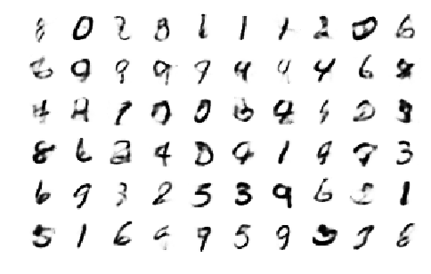

```python
plt.figure(figsize=(8,50)) # not shown in the book
for iteration in range(n_digits):
    plt.subplot(n_digits, 10, iteration + 1)
    plot_image(outputs_val[iteration])
```

## 8. Other Autoencoders

autoencoder와 다른 비지도 학습알고리즘의 새로운 아키텍쳐들은 계속 개발되고있다.

- Contractive autoencoder(CAE) 두개의 비슷한 input은 비슷한 coding을 가져야한다.
- Stacked convolutional autoencoders convolutional layer를 통해 이미지 처리를 재구성함으로써 시각적 feature들을 뽑아내는것을 학습하는 autoencoder
- Generative stochastic network(GSN) denoising autoencoder의 일반화
- Winner-take-all(WTA) autoencoder 이것은 sparse coding으로 이끈다. 비슷한 WTA 접근법은 sparse convolutional autoencoder를 만드는데에 사용될 수 있다.
- Adversarial autoencoders 한 네트워크는 이것의 input를 재생산하기위해 학습된다. 그리고 동시에 또다른 것은 첫번째 네트워크가 적절히 재구성하지 못한 input를 찾기위해 학습된다.